# Predicting stock returns using ML modelling

Webster Zhou

Loading relevant packages:

```r
library(tidyverse)
library(glmnet)
library(randomForest)
library(caTools)
library(yardstick)
library(ROCR)
library(cowplot)
```

Setting seed for reproductivity:

```r
set.seed(9999)
```

## 1. Introduction

In financial economics, a key area of interest is to understand asset pricing and to satisfactorily model the behaviour of assets based on a given information set. Although traditional econometric techniques such OLS regressions are greatly used in establishing causal relationships between variables, their forecasting capabilities are notoriously weak.

With the rise of big data machine learning, there is a strong push to leverage these methods in financial economics. While a wide range of information is available for listed companies, it is only in recent years that analysts are studying these data with such deep scrutiny. On that note, this essay will use machine learning methods to forecast stock returns.

## 2. Data

Loading the data:

```r
dat_2014= read_csv("2014_Financial_Data.csv")
dat_2015= read_csv("2015_Financial_Data.csv")
dat_2016= read_csv("2016_Financial_Data.csv")
dat_2017= read_csv("2017_Financial_Data.csv")
dat_2018= read_csv("2018_Financial_Data.csv")
```

### 2.1. Cleaning data

To better understand the upcoming analyses, it will be useful to understand some of the variables that will be used:

1. `X1` is a vector that contains the company names of every stock.
2. `Class` (later renamed to `invest`) is a dummy variable that is 1 if a given stock sees positive growth in period $(t+1)$ and 0 otherwise. It can be interpreted as an indicator for whether the stock is worth investing in hindsight.
3. `lagged_growth` is a lagging variable that displays the percentage price variation of a given stock in the previous year.

The variable `invest` will be used as the outcome variable; different models will be trained to predict the value of `invest` for a stock based on the given set of financial indicators.

To begin with, the data is cleaned:

```r
# Combining datasets
combined_dat= bind_rows(dat_2014,
                        dat_2015,
                        dat_2016,
                        dat_2017,
                        dat_2018)

# Removing duplicate variables
duplicates= combined_dat %>%
    names() %>%
    tolower() %>%
    duplicated()

combined_dat= combined_dat[!duplicates]

# Adding year dummies
combined_dat= combined_dat %>%
                    mutate(year= c(rep(2014,times=nrow(dat_2014)),
                                   rep(2015,times=nrow(dat_2015)),
                                   rep(2016,times=nrow(dat_2016)),
                                   rep(2017,times=nrow(dat_2017)),
                                   rep(2018,times=nrow(dat_2018))) %>%
                             factor(),
                           invest=factor(Class),
                           sector= factor(Sector)) %>%
  select(-Class, -Sector)


# Keeping only those companies that show up in all five datasets
common_companies= combined_dat %>%
    select(X1) %>%
    count(X1) %>%
    filter(n==5) %>%
    pull(X1)

combined_dat =combined_dat %>%
    filter(X1 %in% common_companies) %>%
    arrange(X1)

combined_dat %>%
      distinct(X1) %>% glimpse
```

```
## Observations: 3,726
## Variables: 1
## $ X1 <chr> "A", "AA", "AABA", "AAL", "AAMC", "AAME", "AAN", "AAOI", "AAON", "…
```

```r
# Constructing lagged_growth variable.
lagged_growth= rep(NA, times=nrow(combined_dat))

growth_15 = combined_dat %>%
                  pull(`2015 PRICE VAR [%]`)
lagged_growth[seq(3,nrow(combined_dat),5)] = growth_15[seq(1,nrow(combined_dat),5)]

growth_16 = combined_dat %>%
                  pull(`2016 PRICE VAR [%]`)
lagged_growth[seq(4,nrow(combined_dat),5)] = growth_16[seq(2,nrow(combined_dat),5)]

growth_17 = combined_dat %>%
                  pull(`2017 PRICE VAR [%]`)
lagged_growth[seq(5,nrow(combined_dat),5)] = growth_17[seq(3,nrow(combined_dat),5)]

lagged_growth %>% glimpse
```

```
##  num [1:18630] NA NA 4.18 13.19 45.35 ...
```

```r
# Removing variables with significant missing entries
combined_dat= combined_dat %>%
          mutate(lagged_growth= lagged_growth) %>%
          select(-`2015 PRICE VAR [%]`,
                 -`2016 PRICE VAR [%]`,
                 -`2017 PRICE VAR [%]`,
                 -`2018 PRICE VAR [%]`,
                 -`2019 PRICE VAR [%]`)

combined_dat= combined_dat %>%
                        filter(year==2016 | year==2017 | year==2018)


# Removing outliers (<1 or >99 percentiles)
remove_outliers = function(x, remove_na = TRUE) {
  qnt = quantile(x, probs=c(.01, .99), na.rm = remove_na)
  y = x
  y[x < qnt[1] ] = NA
  y[x > qnt[2] ] = NA
  y
}

remove_all_outliers = function(df){
  df[,sapply(df, is.numeric)] = lapply(df[,sapply(df, is.numeric)], remove_outliers)
  df
}

combined_dat= remove_all_outliers(combined_dat)


# Removing observations with missing entries
remove_vars= combined_dat %>%
    select_if(function(x){sum(is.na(x))>2000}) %>%
    names()

combined_dat = combined_dat %>% select(-remove_vars)

complete_rows= complete.cases(combined_dat)
combined= combined_dat[complete_rows,]
```

Having a top-level look of the cleaned dataset shows that there are up to 189 variables that can be used to help predict the value of `invest`.

```r
combined %>% glimpse
```

```
## Observations: 3,547
## Variables: 190
## $ X1                                          <chr> "A", "A", "A", "AAN", "AA…
## $ Revenue                                     <dbl> 4202000000, 4472000000, 4…
## $ `Revenue Growth`                            <dbl> 0.0406, 0.0643, 0.0988, 0…
## $ `Cost of Revenue`                           <dbl> 2005000000, 2063000000, 2…
## $ `Gross Profit`                              <dbl> 2197000000, 2409000000, 2…
## $ `R&D Expenses`                              <dbl> 329000000, 339000000, 385…
## $ `SG&A Expense`                              <dbl> 1253000000, 1229000000, 1…
## $ `Operating Expenses`                        <dbl> 1582000000, 1568000000, 1…
## $ `Operating Income`                          <dbl> 615000000, 841000000, 928…
## $ `Interest Expense`                          <dbl> 72000000, 79000000, 75000…
## $ `Earnings before Tax`                       <dbl> 544000000, 803000000, 946…
## $ `Income Tax Expense`                        <dbl> 82000000, 119000000, 6300…
## $ `Net Income - Non-Controlling int`          <dbl> 0, 0, 0, 0, 0, 0, 0, 0, 0…
```

[output cut: 177 more lines]

### 2.2. Constructing training and testing samples

The next step is to split the dataset into training and testing samples. The data is split such that 80% goes into training the model, and 20% will be used to evaluate the trained model. In doing so, the training dataset consists of 2837 observations and the testing dataset consists of 710 observations.

```r
y = tibble(company_name= combined$X1,
           preceding_year= combined$year,
           invest= combined$invest)

x= combined %>%
    select(-c(X1, invest)) %>%
    select_if(function(k){length(unique(k))>1})

x=  model.matrix(~.,x)

sample = sample.split(y$invest, SplitRatio = .8)

x_train = subset(x, sample == TRUE)
x_test  = subset(x, sample == FALSE)

y_train = subset(y, sample == TRUE)
y_test  = subset(y, sample == FALSE)

x_train %>% dim
```

```
## [1] 2837  200
```

```r
x_test %>% dim
```

```
## [1] 710 200
```

## 3. Analysis

5 models will be used to forecast the outcome variable `invest`:

1. Lasso
2. Adaptive lasso
3. Elastic Net
4. Adaptive Elastic Net
5. Random Forest

The choice of methods stems from the nature of this dataset and the characteristics of each method. While OLS models are often used as a “baseline” model for comparing to other more complex models, this analysis will not do so because of its poor model selection capabilities (under rejecting insignificant variables); the same argument applies to the ridge regression, which has no element of model selection at all.

### 3.1. Lasso and adaptive lasso

Lasso regression has a $\ell_1$ penalisation that helps in model selection, while the adaptive lasso is a natural extension of the lasso and its performance will be evaluated too. Here, the optimal penalisation parameter $\lambda^*$ is chosen using the cross-validation method.

```r
# Lasso
cv_lasso= cv.glmnet(y = y_train$invest,
                    x = x_train,
                    type.measure = "class",
                    family="binomial"
                    )


# Adaptive Lasso
omega= 1/ abs(coef(cv_lasso,s = "lambda.min"))
omega[omega==Inf] = 9999999


cv_adalasso = cv.glmnet(y = y_train$invest,
                     x = x_train,
                     penalty.factor=omega,
                     type.measure = "class",
                     family="binomial")
```

### 3.2. Elastic net and adaptive elastic net

The elastic net methods combine both $\ell_1$ and $\ell_2$ penalities and may outperform $\ell_1$ penalisation methods in some cases. Therefore, it is worth including them as well. $\alpha$ is set at $0.5$ to allow 50% weightage on both $\ell_1$ and $\ell_2$ penalisations.

```r
#Elastic Net
enet= cv.glmnet(y = y_train$invest,
                    x = x_train,
                    type.measure = "class",
                    family="binomial",
                    alpha= 0.5
                    )


#Adaptive Elastic Net
omega2= 1/ abs(coef(enet,s = "lambda.min"))
omega2[omega2==Inf] = 9999999


aenet= cv.glmnet(y = y_train$invest,
                    x = x_train,
                    type.measure = "class",
                    family="binomial",
                    alpha= 0.5,
                    penalty.factor=omega2
                    )
```

### 3.3. Random forest

One key drawback with penalised estimation methods is the imposition of a linear structure of the outcome variable: ie. $y_i = \boldsymbol{X}_i \boldsymbol{\beta} + \epsilon_i$. That is a strong assumption that may not hold in practice. The random forest is a model that incorporates non-linearities, ie. $y_i = f(x_{i1} +...+x_{ik}) + \epsilon_i$; hence it is chosen as a supplement to other methods.

```r
#Random Forest
forest= randomForest(y = y_train$invest,
                     x = x_train,
                     ntree = 2000,
                     importance = TRUE
                     )
```

## 4. Evaluating model performance

The final steps are to evaluate the performance of each model and to pick out the best-performing model. To do so, each model will make predictions on the outcome for observations in the testing dataset. These predictions will be compared to actual outcomes and then evaluated using different metrics to understand how well each model performs.

It will be helpful to understand how the actual outcomes are distributed in the testing dataset. It appears that over 50% of the stocks have positive returns, which is sensible given the data is taken during an economic boom.

```r
y_test$invest %>% summary
```

```
##   0   1
## 293 417
```

```r
# Constructing predictions in testing dataset
fn_pred = function(model_results, p_type= "response"){
  p = predict(model_results,
                    newx= x_test,
                    type= p_type,
                    s = "lambda.min"
                  ) %>%
    as.numeric()
  p
}

# Aggregating results in a list (for ROC plots)
leg= c("Lasso", "Adaptive Lasso", "Elastic Net", "Adaptive Elastic Net", "Random Forest")
prediction_list= list(fn_pred(cv_lasso),
                      fn_pred(cv_adalasso),
                      fn_pred(enet),
                      fn_pred(aenet),
                      random_forest = predict(forest,
                                              type = "prob",
                                              newdata= x_test,)[,2]
                      ) %>%
                  setNames(leg)

# Creating a corresponding list for actual outcomes (for ROC plots)
actual_list= rep(list(y_test$invest),
                 5)
```

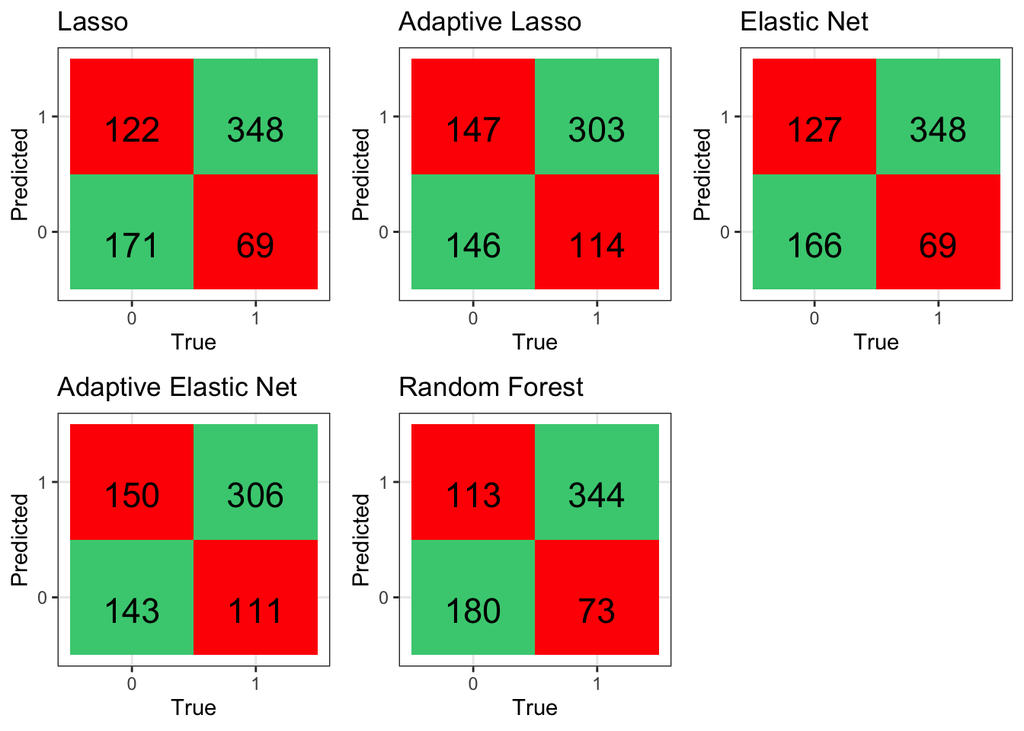

Figure 1: Confusion matrix for each model

[output not shown]

```r
conf_data= bind_cols(pred= prediction_list %>% unlist %>% round,
                     method= rep(leg,each= nrow(y_test)),
                     actual= unlist(actual_list))

# Defining a function to automate plotting of confusion matrix
confusion_matrix_plot= function(metd){

  True = factor(c(0, 0, 1, 1))
  Predicted = factor(c(0, 1, 0, 1))
  Metric = conf_data %>%
          filter(method== metd) %>%
          select(pred, actual) %>%
          table() %>%
          as.numeric()

  df = data.frame(True, Predicted, Metric,
                  goodbad= c("good","bad","bad","good"))

  ggplot(data =  df, aes(x = True , y = Predicted, fill=goodbad)) +
    geom_tile() +
    geom_text(aes(label = sprintf("%1.0f", Metric)), vjust = 1, size=6) +
    scale_fill_manual(values = c(bad= "red", good= "seagreen3"))+
    theme_bw() + theme(legend.position = "none") +
    labs(title = metd)
  }

conf_mat_list= lapply(leg, function(x){confusion_matrix_plot(x)})

plot_grid(conf_mat_list[[1]],
          conf_mat_list[[2]],
          conf_mat_list[[3]],
          conf_mat_list[[4]],
          conf_mat_list[[5]])
```

Beyond these metrics, one can also investigate the *recall-precision curve* and *ROC* using predicted probabilities. As the number of positive observations stands in the majority, *recall-precision* is less useful because the ability to correctly detect negative samples is more important than correctly detecting positive ones. Hence, the *ROC* (depicted using the *ROC curve*), which plots sensitivity (true positive rate) against ($1-$specificity) (false positive rate) for a given threshold $\theta$, is better suited for this dataset.

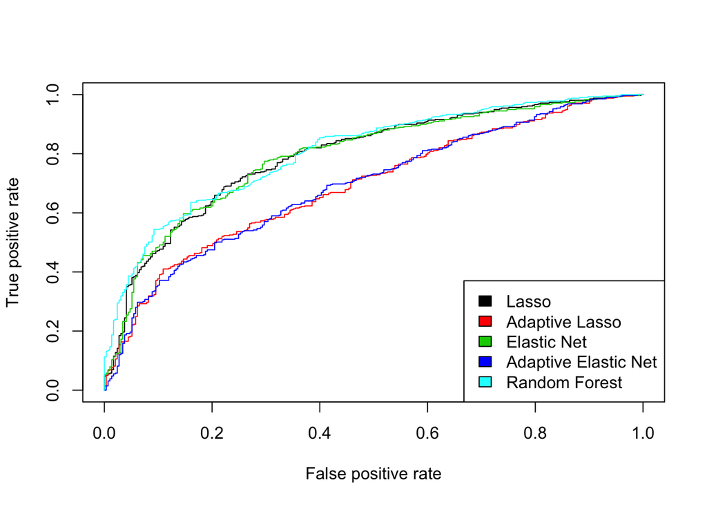

Figure 2: ROC Curves

```r
predictions= prediction(prediction_list,
                        actual_list)

roc_curves = performance(predictions,
                         "tpr", "fpr")

plot(roc_curves, col = as.list(1:5))
legend(x = "bottomright",
       legend = leg,
       fill = 1:5)
```

## 5. Conclusion

Overall, the lasso, elastic net models perform better than the adaptive versions, and the random forest appears to have the edge in overall performance. Model selection ultimately lies in the user’s objectives and appetite for risk. If one cares less about losses and wants a model that is best in picking out good stocks, the lasso and elastic net models are optimal.